# PCA_script

Francisco Carranza

2024-03-19

# [Franco](https://github.com/altsplicer) / [*DEseq2 PCA*](https://altsplicer.github.io/PCA_script/PCA_RMD.html)

[figure not shown]

[figure not shown]

## Overview

This a walk-through of the PCA plot script used for Met Cancer project in the Hertel and Kaiser lab. There is a built in PCA command in the DEseq2 R package. For a Deseq2 tutorial/walkthrough see https://altsplicer.github.io/DEseq2_Script/DESEQ2_met.html. You can also see this walk-through via this [link](https://altsplicer.github.io/PCA_script/PCA_RMD.html). # PCA plots are used as QC check in your RNA-seq analysis. To explore the similarity of our samples and identify outliers. # Highly recommended to do prior to your differential expression analysis. # For a more indepth view of QC checks such as PCA plots and unsupervised clustering see the following [link](https://hbctraining.github.io/DGE_workshop/lessons/03_DGE_QC_analysis.html).

## Install and Load DEseq2 and ggplot2 in R studio

```r
# installion of DESEQ2 via Biocmanager and ggplot2
#BiocManager::install("DESeq2")
#install.packages("ggplot2")
# Call required packages
library(DESeq2)
library(ggplot2)
```

## Locate your reads count file

The input file will be a the output text file from the STAR aligner, geneCounts or a feature counts text file.

```r
# location of read counts text file
# infile = "./example.txt"
infile = "./com_0v120v720counts.txt"
```

## Setup the experimental design

```r
# design for 3 reps, 6 conditions
design = c( "3", "3", "3", "3", "3", "3")
# design for 2 reps 4 conditions
# design = c( "2", "2", "2", "2")

# call the design and transform them into a integer character.
reps1 = as.integer(design[1])
reps2 = as.integer(design[2])
reps3 = as.integer(design[3])
reps4 = as.integer(design[4])
reps5 = as.integer(design[5])
reps6 = as.integer(design[6])

# Set up the conditions based on the experimental setup.
# cond1 = rep("cond1", reps1)
# cond2 = rep("cond2", reps2)

cond1 = rep("MB_000", reps1)
cond2 = rep("R8_000", reps2)
cond3 = rep("MB_120", reps3)
cond4 = rep("R8_120", reps4)
cond5 = rep("MB_720", reps5)
cond6 = rep("R8_720", reps6)
```

# Read the data from the standard input.

```r
counts = read.table(infile, header=TRUE, sep="\t", row.names=1 )

# Optional, head the counts to view the formatting and adjust accordingly
#head(counts, 5)
```

# Edit the counts matrix

The count data so the only the read counts and gene name remains.

```r
# Assume the last columns are the count matrix.
#idx = ncol(counts) - (reps1 + reps2)
idx = ncol(counts) - (reps1 + reps2 + reps3 + reps4 + reps5 + reps6)

# Cut out the valid columns.
# counts = counts[-c(1:idx)]
counts = counts[-c(1:idx)]

# Some tools generate the estimated counts as real numbers
# DESeq 2 allows only integers. We need to convert real numbers to rounded integers.
numeric_idx = sapply(counts, mode) == 'numeric'
counts[numeric_idx] = round(counts[numeric_idx], 0)
head(counts, 5)
```

```
##          MB468_000_01 MB468_000_02 MB468_000_03 R8_000_01 R8_000_02 R8_000_03
## C1orf141            0            0            0         0         0         0
## PKP1               48           42           28        79        68        37
## RERE             3487         3719         2234      4710      3530      2740
## CSMD2               0            1            2         0         0         0
## HIVEP3            598          638          350       302       254       193
##          MB468_120_01 MB468_120_02 MB468_120_03 R8_120_01 R8_120_02 R8_120_03
## C1orf141            0            0            0         0         0         0
## PKP1              234          170          272        91       175        47
## RERE             2525         1645         2435      3485      5960      2563
## CSMD2               0            0            0         0         0         0
## HIVEP3            447          241          446       314       460       216
##          MB468_720_01 MB468_720_02 MB468_720_03 R8_720_01 R8_720_02 R8_720_03
## C1orf141            0            0            0         0         0         0
## PKP1              646          398          562        41        33        25
## RERE             4331         2484         4481      4023      2894      3657
## CSMD2               0            0            0         0         0         0
## HIVEP3           1082          523         1011       381       324       331
```

# Build the dataset names and conditions

```r
samples = names(counts)
condition = factor(c(cond1, cond2, cond3, cond4, cond5, cond6))
colData = data.frame(samples=samples, condition=condition)

# You can view the dataset by calling the following
samples
```

```
##  [1] "MB468_000_01" "MB468_000_02" "MB468_000_03" "R8_000_01"    "R8_000_02"
##  [6] "R8_000_03"    "MB468_120_01" "MB468_120_02" "MB468_120_03" "R8_120_01"
## [11] "R8_120_02"    "R8_120_03"    "MB468_720_01" "MB468_720_02" "MB468_720_03"
## [16] "R8_720_01"    "R8_720_02"    "R8_720_03"
```

```r
condition
```

```
##  [1] MB_000 MB_000 MB_000 R8_000 R8_000 R8_000 MB_120 MB_120 MB_120 R8_120
## [11] R8_120 R8_120 MB_720 MB_720 MB_720 R8_720 R8_720 R8_720
## Levels: MB_000 MB_120 MB_720 R8_000 R8_120 R8_720
```

```r
colData
```

```
##         samples condition
## 1  MB468_000_01    MB_000
## 2  MB468_000_02    MB_000
## 3  MB468_000_03    MB_000
## 4     R8_000_01    R8_000
## 5     R8_000_02    R8_000
## 6     R8_000_03    R8_000
## 7  MB468_120_01    MB_120
## 8  MB468_120_02    MB_120
## 9  MB468_120_03    MB_120
## 10    R8_120_01    R8_120
## 11    R8_120_02    R8_120
## 12    R8_120_03    R8_120
## 13 MB468_720_01    MB_720
## 14 MB468_720_02    MB_720
## 15 MB468_720_03    MB_720
## 16    R8_720_01    R8_720
## 17    R8_720_02    R8_720
## 18    R8_720_03    R8_720
```

# Create DESEq2 dataset.

```r
#dds = DESeqDataSetFromMatrix(countData=counts, colData=colData, design = ~condition)
dds = DESeqDataSetFromMatrix(countData=counts, colData=colData, design = ~condition)
```

# Run deseq2.

```r
dds = DESeq(dds)
```

# Transform counts for PCA

vst will transform your counts for data visualization.

```r
# object refers to a DESeqDataSet or a matrix of counts.
# blind see documentation for an explanation.
#vst(object, blind=TRUE)
vsdata <- vst(dds, blind=TRUE)
```

# Plot a simple PCA plot

```
## using ntop=500 top features by variance
```

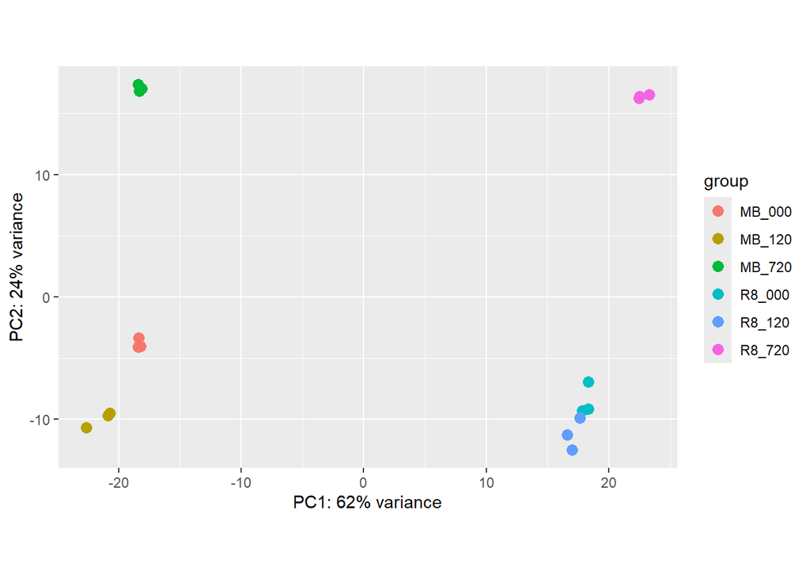

```r
plotPCA(vsdata, intgroup=c("condition"))
```

# Further Customization

Run the previous command but instead of plotting a PCA plot your output will return a data frame and store it in “pcaData”.

```r
# pcaData <- plotPCA(vsdata, intgroup=c("condition", "type"), returnData=TRUE)
pcaData <- plotPCA(vsdata, intgroup=c("condition"), returnData=TRUE)
```

```
## using ntop=500 top features by variance
```

```r
#retrieve the percent variance for PC1 and PC2 in the PCA plot
percentVar <- round(100 * attr(pcaData, "percentVar"))
```

Plot the PCA plot using ggplot and the “pcaData” dataframe made using the plotPCA command.

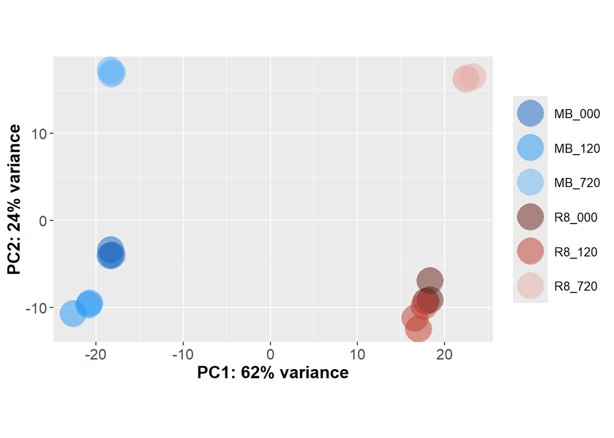

```r
# Use ggplot2 options to change the plot colors, font size and many other plot options.
ggplot(pcaData, aes(PC1, PC2, color=condition)) +
  geom_point(size=10,alpha=0.5) +
  xlab(paste0("PC1: ",percentVar[1],"% variance")) +
  ylab(paste0("PC2: ",percentVar[2],"% variance")) +
  coord_fixed() + scale_color_manual(values = c("#1565C0","#2196F3","#64B5F6","#641E16","#C0392B","#E6B0AA")) +
  theme(legend.title=element_blank()) + theme(axis.title=element_text(size=14,face="bold")) + theme(axis.text.x=element_text(size=12))+
  theme(axis.text.y=element_text(size=12)) + theme(legend.text=element_text(size=10))
```

## Acknowledgments

1. Page header logo is adapted from images: [DESeq2-Michael-Love.png]